# Risk Factor Analysis

## Outcome Variable

**Outcome Variable:** sstunted

## Predictor Variables

**Intervention Variable:** anywast06

**Adjustment Set:**

unadjusted

## Stratifying Variables

The analysis was stratified on these variable(s):

- agecat
- studyid
- country

## Data Summary

| agecat | studyid | country | anywast06 | sstunted | n_cell | n |
| --- | --- | --- | --- | --- | --- | --- |
| Birth | CMC-V-BCS-2002 | INDIA | 0 | 0 | 37 | 92 |
| Birth | CMC-V-BCS-2002 | INDIA | 0 | 1 | 0 | 92 |
| Birth | CMC-V-BCS-2002 | INDIA | 1 | 0 | 51 | 92 |
| Birth | CMC-V-BCS-2002 | INDIA | 1 | 1 | 4 | 92 |
| Birth | CMIN | BANGLADESH | 0 | 0 | 15 | 20 |
| Birth | CMIN | BANGLADESH | 0 | 1 | 0 | 20 |
| Birth | CMIN | BANGLADESH | 1 | 0 | 5 | 20 |
| Birth | CMIN | BANGLADESH | 1 | 1 | 0 | 20 |
| Birth | CONTENT | PERU | 0 | 0 | 2 | 2 |
| Birth | CONTENT | PERU | 0 | 1 | 0 | 2 |
| Birth | CONTENT | PERU | 1 | 0 | 0 | 2 |
| Birth | CONTENT | PERU | 1 | 1 | 0 | 2 |
| Birth | EE | PAKISTAN | 0 | 0 | 119 | 240 |
| Birth | EE | PAKISTAN | 0 | 1 | 37 | 240 |
| Birth | EE | PAKISTAN | 1 | 0 | 73 | 240 |
| Birth | EE | PAKISTAN | 1 | 1 | 11 | 240 |
| Birth | GMS-Nepal | NEPAL | 0 | 0 | 406 | 684 |
| Birth | GMS-Nepal | NEPAL | 0 | 1 | 16 | 684 |
| Birth | GMS-Nepal | NEPAL | 1 | 0 | 257 | 684 |
| Birth | GMS-Nepal | NEPAL | 1 | 1 | 5 | 684 |
| Birth | IRC | INDIA | 0 | 0 | 155 | 388 |
| Birth | IRC | INDIA | 0 | 1 | 9 | 388 |
| Birth | IRC | INDIA | 1 | 0 | 217 | 388 |
| Birth | IRC | INDIA | 1 | 1 | 7 | 388 |
| Birth | Keneba | GAMBIA | 0 | 0 | 970 | 1542 |
| Birth | Keneba | GAMBIA | 0 | 1 | 24 | 1542 |
| Birth | Keneba | GAMBIA | 1 | 0 | 543 | 1542 |
| Birth | Keneba | GAMBIA | 1 | 1 | 5 | 1542 |
| Birth | MAL-ED | BANGLADESH | 0 | 0 | 170 | 229 |
| Birth | MAL-ED | BANGLADESH | 0 | 1 | 7 | 229 |

[output cut: 170 more lines]

The following strata were considered:

- agecat: 24 months, studyid: CMC-V-BCS-2002, country: INDIA
- agecat: 24 months, studyid: CMIN, country: BANGLADESH
- agecat: 24 months, studyid: CONTENT, country: PERU
- agecat: 24 months, studyid: EE, country: PAKISTAN
- agecat: 24 months, studyid: GMS-Nepal, country: NEPAL
- agecat: 24 months, studyid: IRC, country: INDIA
- agecat: 24 months, studyid: Keneba, country: GAMBIA
- agecat: 24 months, studyid: MAL-ED, country: BANGLADESH
- agecat: 24 months, studyid: MAL-ED, country: BRAZIL
- agecat: 24 months, studyid: MAL-ED, country: INDIA
- agecat: 24 months, studyid: MAL-ED, country: NEPAL
- agecat: 24 months, studyid: MAL-ED, country: PERU
- agecat: 24 months, studyid: MAL-ED, country: SOUTH AFRICA
- agecat: 24 months, studyid: MAL-ED, country: TANZANIA, UNITED REPUBLIC OF
- agecat: 24 months, studyid: PROVIDE, country: BANGLADESH
- agecat: 24 months, studyid: TanzaniaChild2, country: TANZANIA, UNITED REPUBLIC OF
- agecat: 6 months, studyid: CMC-V-BCS-2002, country: INDIA
- agecat: 6 months, studyid: CMIN, country: BANGLADESH
- agecat: 6 months, studyid: CONTENT, country: PERU
- agecat: 6 months, studyid: EE, country: PAKISTAN
- agecat: 6 months, studyid: GMS-Nepal, country: NEPAL
- agecat: 6 months, studyid: Guatemala BSC, country: GUATEMALA
- agecat: 6 months, studyid: IRC, country: INDIA
- agecat: 6 months, studyid: Keneba, country: GAMBIA
- agecat: 6 months, studyid: MAL-ED, country: BANGLADESH
- agecat: 6 months, studyid: MAL-ED, country: BRAZIL
- agecat: 6 months, studyid: MAL-ED, country: INDIA
- agecat: 6 months, studyid: MAL-ED, country: NEPAL
- agecat: 6 months, studyid: MAL-ED, country: PERU
- agecat: 6 months, studyid: MAL-ED, country: SOUTH AFRICA
- agecat: 6 months, studyid: MAL-ED, country: TANZANIA, UNITED REPUBLIC OF
- agecat: 6 months, studyid: PROVIDE, country: BANGLADESH
- agecat: 6 months, studyid: ResPak, country: PAKISTAN
- agecat: 6 months, studyid: TanzaniaChild2, country: TANZANIA, UNITED REPUBLIC OF
- agecat: Birth, studyid: CMC-V-BCS-2002, country: INDIA
- agecat: Birth, studyid: CMIN, country: BANGLADESH
- agecat: Birth, studyid: CONTENT, country: PERU
- agecat: Birth, studyid: EE, country: PAKISTAN
- agecat: Birth, studyid: GMS-Nepal, country: NEPAL
- agecat: Birth, studyid: IRC, country: INDIA
- agecat: Birth, studyid: Keneba, country: GAMBIA
- agecat: Birth, studyid: MAL-ED, country: BANGLADESH
- agecat: Birth, studyid: MAL-ED, country: BRAZIL
- agecat: Birth, studyid: MAL-ED, country: INDIA
- agecat: Birth, studyid: MAL-ED, country: NEPAL
- agecat: Birth, studyid: MAL-ED, country: PERU
- agecat: Birth, studyid: MAL-ED, country: SOUTH AFRICA
- agecat: Birth, studyid: MAL-ED, country: TANZANIA, UNITED REPUBLIC OF
- agecat: Birth, studyid: PROVIDE, country: BANGLADESH
- agecat: Birth, studyid: ResPak, country: PAKISTAN

### Dropped Strata

Some strata were dropped due to rare outcomes:

- agecat: Birth, studyid: CMC-V-BCS-2002, country: INDIA
- agecat: Birth, studyid: CMIN, country: BANGLADESH
- agecat: Birth, studyid: CONTENT, country: PERU
- agecat: Birth, studyid: MAL-ED, country: BANGLADESH
- agecat: Birth, studyid: MAL-ED, country: BRAZIL
- agecat: Birth, studyid: MAL-ED, country: INDIA
- agecat: Birth, studyid: MAL-ED, country: NEPAL
- agecat: Birth, studyid: MAL-ED, country: PERU
- agecat: Birth, studyid: MAL-ED, country: SOUTH AFRICA
- agecat: Birth, studyid: MAL-ED, country: TANZANIA, UNITED REPUBLIC OF
- agecat: Birth, studyid: PROVIDE, country: BANGLADESH
- agecat: Birth, studyid: ResPak, country: PAKISTAN
- agecat: 6 months, studyid: CONTENT, country: PERU
- agecat: 6 months, studyid: Guatemala BSC, country: GUATEMALA
- agecat: 6 months, studyid: MAL-ED, country: BANGLADESH
- agecat: 6 months, studyid: MAL-ED, country: BRAZIL
- agecat: 6 months, studyid: MAL-ED, country: INDIA
- agecat: 6 months, studyid: MAL-ED, country: NEPAL
- agecat: 6 months, studyid: MAL-ED, country: PERU
- agecat: 6 months, studyid: MAL-ED, country: SOUTH AFRICA
- agecat: 6 months, studyid: MAL-ED, country: TANZANIA, UNITED REPUBLIC OF
- agecat: 6 months, studyid: TanzaniaChild2, country: TANZANIA, UNITED REPUBLIC OF
- agecat: 24 months, studyid: CONTENT, country: PERU
- agecat: 24 months, studyid: MAL-ED, country: BRAZIL
- agecat: 24 months, studyid: MAL-ED, country: NEPAL
- agecat: 24 months, studyid: MAL-ED, country: PERU
- agecat: 24 months, studyid: MAL-ED, country: TANZANIA, UNITED REPUBLIC OF
- agecat: 24 months, studyid: TanzaniaChild2, country: TANZANIA, UNITED REPUBLIC OF

## Methods Detail

We’re interested in the causal parameters $E[Y_a]$ for all values of $a \in \mathcal{A}$. These parameters represent the mean outcome if, possibly contrary to fact, we intervened to set all units to have $A=a$. Under the randomization and positivity assumptions, these are identified by the statistical parameters $\psi_a=E_W[E_{Y|A,W}(Y|A=a,W)]$. In addition, we’re interested in the mean of $Y$, $E[Y]$ under no intervention (the observed mean). We will estimate these parameters by using SuperLearner to fit the relevant likelihood factors – $E_{Y|A,W}(Y|A=a,W)$ and $p(A=a|W)$, and then updating our likelihood fit using a joint TMLE.

For unadjusted analyses ($W=\{\}$), initial likelihoods were estimated using Lrnr_glm to estimate the simple $E(Y|A)$ and Lrnr_mean to estimate $p(A)$. For adjusted analyses, a small library containing Lrnr_glmnet, Lrnr_xgboost, and Lrnr_mean was used.

Having estimated these parameters, we will then use the delta method to estimate relative risks and attributable risks relative to a prespecified baseline level of $A$.

# Results Detail

## Results Plots

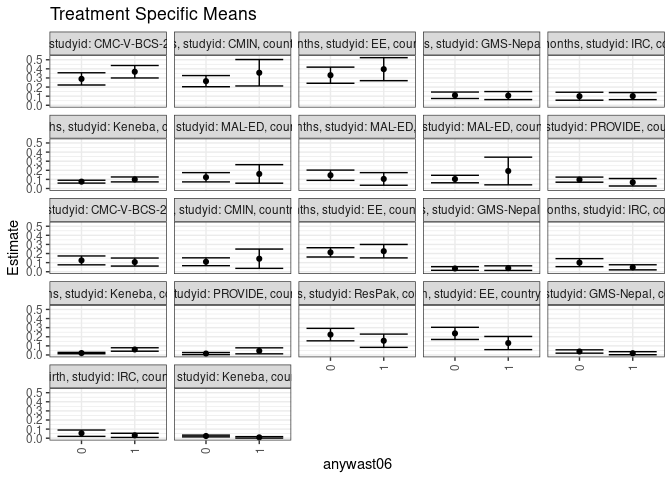

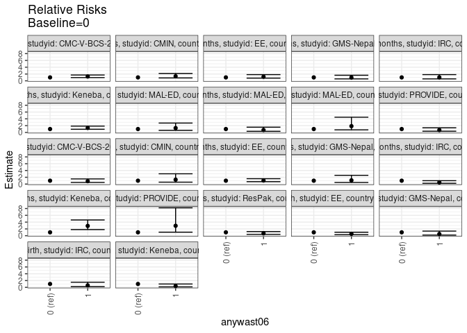

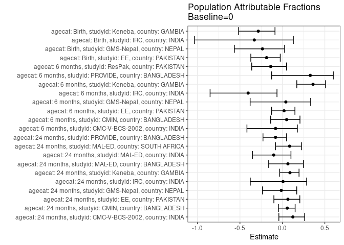

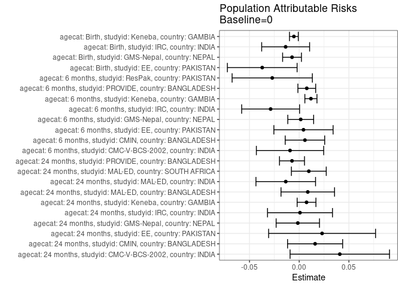

## Results Table

### Parameter: TSM

| agecat | studyid | country | intervention_level | baseline_level | estimate | ci_lower | ci_upper |
| --- | --- | --- | --- | --- | --- | --- | --- |
| Birth | EE | PAKISTAN | 0 | NA | 0.2371795 | 0.1702924 | 0.3040666 |
| Birth | EE | PAKISTAN | 1 | NA | 0.1309524 | 0.0586598 | 0.2032449 |
| Birth | GMS-Nepal | NEPAL | 0 | NA | 0.0379147 | 0.0196791 | 0.0561503 |
| Birth | GMS-Nepal | NEPAL | 1 | NA | 0.0190840 | 0.0025047 | 0.0356632 |
| Birth | IRC | INDIA | 0 | NA | 0.0548780 | 0.0199777 | 0.0897784 |
| Birth | IRC | INDIA | 1 | NA | 0.0312500 | 0.0084353 | 0.0540647 |
| Birth | Keneba | GAMBIA | 0 | NA | 0.0241449 | 0.0145993 | 0.0336904 |
| Birth | Keneba | GAMBIA | 1 | NA | 0.0091241 | 0.0011606 | 0.0170876 |
| 6 months | CMC-V-BCS-2002 | INDIA | 0 | NA | 0.1242938 | 0.0756238 | 0.1729638 |
| 6 months | CMC-V-BCS-2002 | INDIA | 1 | NA | 0.1063830 | 0.0622486 | 0.1505173 |
| 6 months | CMIN | BANGLADESH | 0 | NA | 0.1094527 | 0.0662026 | 0.1527029 |
| 6 months | CMIN | BANGLADESH | 1 | NA | 0.1428571 | 0.0368106 | 0.2489037 |
| 6 months | EE | PAKISTAN | 0 | NA | 0.2128514 | 0.1619420 | 0.2637608 |
| 6 months | EE | PAKISTAN | 1 | NA | 0.2258065 | 0.1521157 | 0.2994972 |
| 6 months | GMS-Nepal | NEPAL | 0 | NA | 0.0357143 | 0.0158539 | 0.0555747 |
| 6 months | GMS-Nepal | NEPAL | 1 | NA | 0.0394737 | 0.0141764 | 0.0647710 |
| 6 months | IRC | INDIA | 0 | NA | 0.1000000 | 0.0561199 | 0.1438801 |
| 6 months | IRC | INDIA | 1 | NA | 0.0484581 | 0.0204898 | 0.0764265 |
| 6 months | Keneba | GAMBIA | 0 | NA | 0.0208189 | 0.0134452 | 0.0281925 |
| 6 months | Keneba | GAMBIA | 1 | NA | 0.0601626 | 0.0413649 | 0.0789604 |
| 6 months | PROVIDE | BANGLADESH | 0 | NA | 0.0155556 | 0.0041126 | 0.0269986 |
| 6 months | PROVIDE | BANGLADESH | 1 | NA | 0.0454545 | 0.0125289 | 0.0783802 |
| 6 months | ResPak | PAKISTAN | 0 | NA | 0.2237762 | 0.1553235 | 0.2922290 |
| 6 months | ResPak | PAKISTAN | 1 | NA | 0.1562500 | 0.0834653 | 0.2290347 |
| 24 months | CMC-V-BCS-2002 | INDIA | 0 | NA | 0.2897727 | 0.2226587 | 0.3568868 |
| 24 months | CMC-V-BCS-2002 | INDIA | 1 | NA | 0.3684211 | 0.2997377 | 0.4371044 |
| 24 months | CMIN | BANGLADESH | 0 | NA | 0.2650000 | 0.2037087 | 0.3262913 |
| 24 months | CMIN | BANGLADESH | 1 | NA | 0.3571429 | 0.2119314 | 0.5023543 |
| 24 months | EE | PAKISTAN | 0 | NA | 0.3302752 | 0.2417178 | 0.4188327 |
| 24 months | EE | PAKISTAN | 1 | NA | 0.3965517 | 0.2702794 | 0.5228241 |
| 24 months | GMS-Nepal | NEPAL | 0 | NA | 0.1100000 | 0.0745575 | 0.1454425 |
| 24 months | GMS-Nepal | NEPAL | 1 | NA | 0.1063830 | 0.0622639 | 0.1505021 |
| 24 months | IRC | INDIA | 0 | NA | 0.0994475 | 0.0557967 | 0.1430983 |
| 24 months | IRC | INDIA | 1 | NA | 0.1008772 | 0.0617374 | 0.1400170 |
| 24 months | Keneba | GAMBIA | 0 | NA | 0.0751604 | 0.0595108 | 0.0908100 |
| 24 months | Keneba | GAMBIA | 1 | NA | 0.0995763 | 0.0725543 | 0.1265983 |
| 24 months | MAL-ED | BANGLADESH | 0 | NA | 0.1234568 | 0.0726804 | 0.1742331 |
| 24 months | MAL-ED | BANGLADESH | 1 | NA | 0.1600000 | 0.0581433 | 0.2618567 |
| 24 months | MAL-ED | INDIA | 0 | NA | 0.1456954 | 0.0892995 | 0.2020913 |
| 24 months | MAL-ED | INDIA | 1 | NA | 0.1052632 | 0.0361142 | 0.1744122 |
| 24 months | MAL-ED | SOUTH AFRICA | 0 | NA | 0.1037736 | 0.0626352 | 0.1449119 |
| 24 months | MAL-ED | SOUTH AFRICA | 1 | NA | 0.1923077 | 0.0404989 | 0.3441165 |
| 24 months | PROVIDE | BANGLADESH | 0 | NA | 0.0972222 | 0.0692610 | 0.1251834 |
| 24 months | PROVIDE | BANGLADESH | 1 | NA | 0.0684932 | 0.0274856 | 0.1095007 |

### Parameter: E(Y)

| agecat | studyid | country | intervention_level | baseline_level | estimate | ci_lower | ci_upper |
| --- | --- | --- | --- | --- | --- | --- | --- |
| Birth | EE | PAKISTAN | NA | NA | 0.2000000 | 0.1492882 | 0.2507118 |
| Birth | GMS-Nepal | NEPAL | NA | NA | 0.0307018 | 0.0177643 | 0.0436392 |
| Birth | IRC | INDIA | NA | NA | 0.0412371 | 0.0214268 | 0.0610475 |
| Birth | Keneba | GAMBIA | NA | NA | 0.0188067 | 0.0120244 | 0.0255891 |
| 6 months | CMC-V-BCS-2002 | INDIA | NA | NA | 0.1150685 | 0.0822869 | 0.1478501 |
| 6 months | CMIN | BANGLADESH | NA | NA | 0.1152263 | 0.0749980 | 0.1554547 |
| 6 months | EE | PAKISTAN | NA | NA | 0.2171582 | 0.1752594 | 0.2590570 |
| 6 months | GMS-Nepal | NEPAL | NA | NA | 0.0372340 | 0.0215945 | 0.0528736 |
| 6 months | IRC | INDIA | NA | NA | 0.0712531 | 0.0462303 | 0.0962759 |
| 6 months | Keneba | GAMBIA | NA | NA | 0.0325875 | 0.0249109 | 0.0402642 |
| 6 months | PROVIDE | BANGLADESH | NA | NA | 0.0231788 | 0.0111688 | 0.0351888 |
| 6 months | ResPak | PAKISTAN | NA | NA | 0.1966527 | 0.1461562 | 0.2471492 |
| 24 months | CMC-V-BCS-2002 | INDIA | NA | NA | 0.3306011 | 0.2823401 | 0.3788621 |
| 24 months | CMIN | BANGLADESH | NA | NA | 0.2809917 | 0.2242434 | 0.3377401 |
| 24 months | EE | PAKISTAN | NA | NA | 0.3532934 | 0.2805798 | 0.4260070 |
| 24 months | GMS-Nepal | NEPAL | NA | NA | 0.1086066 | 0.0809724 | 0.1362407 |
| 24 months | IRC | INDIA | NA | NA | 0.1002445 | 0.0711031 | 0.1293859 |
| 24 months | Keneba | GAMBIA | NA | NA | 0.0825336 | 0.0688872 | 0.0961800 |
| 24 months | MAL-ED | BANGLADESH | NA | NA | 0.1320755 | 0.0863920 | 0.1777589 |
| 24 months | MAL-ED | INDIA | NA | NA | 0.1321586 | 0.0880054 | 0.1763117 |
| 24 months | MAL-ED | SOUTH AFRICA | NA | NA | 0.1134454 | 0.0730697 | 0.1538211 |
| 24 months | PROVIDE | BANGLADESH | NA | NA | 0.0899654 | 0.0666186 | 0.1133122 |

### Parameter: RR

| agecat | studyid | country | intervention_level | baseline_level | estimate | ci_lower | ci_upper |
| --- | --- | --- | --- | --- | --- | --- | --- |
| Birth | EE | PAKISTAN | 0 | 0 | 1.0000000 | 1.0000000 | 1.0000000 |
| Birth | EE | PAKISTAN | 1 | 0 | 0.5521236 | 0.2970378 | 1.0262682 |
| Birth | GMS-Nepal | NEPAL | 0 | 0 | 1.0000000 | 1.0000000 | 1.0000000 |
| Birth | GMS-Nepal | NEPAL | 1 | 0 | 0.5033397 | 0.1864681 | 1.3586822 |
| Birth | IRC | INDIA | 0 | 0 | 1.0000000 | 1.0000000 | 1.0000000 |
| Birth | IRC | INDIA | 1 | 0 | 0.5694444 | 0.2162511 | 1.4994928 |
| Birth | Keneba | GAMBIA | 0 | 0 | 1.0000000 | 1.0000000 | 1.0000000 |
| Birth | Keneba | GAMBIA | 1 | 0 | 0.3778893 | 0.1449574 | 0.9851193 |
| 6 months | CMC-V-BCS-2002 | INDIA | 0 | 0 | 1.0000000 | 1.0000000 | 1.0000000 |
| 6 months | CMC-V-BCS-2002 | INDIA | 1 | 0 | 0.8558994 | 0.4838038 | 1.5141753 |
| 6 months | CMIN | BANGLADESH | 0 | 0 | 1.0000000 | 1.0000000 | 1.0000000 |
| 6 months | CMIN | BANGLADESH | 1 | 0 | 1.3051948 | 0.5629336 | 3.0261714 |
| 6 months | EE | PAKISTAN | 0 | 0 | 1.0000000 | 1.0000000 | 1.0000000 |
| 6 months | EE | PAKISTAN | 1 | 0 | 1.0608643 | 0.7078497 | 1.5899321 |
| 6 months | GMS-Nepal | NEPAL | 0 | 0 | 1.0000000 | 1.0000000 | 1.0000000 |
| 6 months | GMS-Nepal | NEPAL | 1 | 0 | 1.1052632 | 0.4731170 | 2.5820391 |
| 6 months | IRC | INDIA | 0 | 0 | 1.0000000 | 1.0000000 | 1.0000000 |
| 6 months | IRC | INDIA | 1 | 0 | 0.4845815 | 0.2346882 | 1.0005583 |
| 6 months | Keneba | GAMBIA | 0 | 0 | 1.0000000 | 1.0000000 | 1.0000000 |
| 6 months | Keneba | GAMBIA | 1 | 0 | 2.8898103 | 1.8019869 | 4.6343310 |
| 6 months | PROVIDE | BANGLADESH | 0 | 0 | 1.0000000 | 1.0000000 | 1.0000000 |
| 6 months | PROVIDE | BANGLADESH | 1 | 0 | 2.9220779 | 1.0407048 | 8.2045740 |
| 6 months | ResPak | PAKISTAN | 0 | 0 | 1.0000000 | 1.0000000 | 1.0000000 |
| 6 months | ResPak | PAKISTAN | 1 | 0 | 0.6982422 | 0.3999276 | 1.2190760 |
| 24 months | CMC-V-BCS-2002 | INDIA | 0 | 0 | 1.0000000 | 1.0000000 | 1.0000000 |
| 24 months | CMC-V-BCS-2002 | INDIA | 1 | 0 | 1.2714138 | 0.9444168 | 1.7116311 |
| 24 months | CMIN | BANGLADESH | 0 | 0 | 1.0000000 | 1.0000000 | 1.0000000 |
| 24 months | CMIN | BANGLADESH | 1 | 0 | 1.3477089 | 0.8441994 | 2.1515287 |
| 24 months | EE | PAKISTAN | 0 | 0 | 1.0000000 | 1.0000000 | 1.0000000 |
| 24 months | EE | PAKISTAN | 1 | 0 | 1.2006705 | 0.7918360 | 1.8205913 |
| 24 months | GMS-Nepal | NEPAL | 0 | 0 | 1.0000000 | 1.0000000 | 1.0000000 |
| 24 months | GMS-Nepal | NEPAL | 1 | 0 | 0.9671180 | 0.5720043 | 1.6351578 |
| 24 months | IRC | INDIA | 0 | 0 | 1.0000000 | 1.0000000 | 1.0000000 |
| 24 months | IRC | INDIA | 1 | 0 | 1.0143762 | 0.5646439 | 1.8223153 |
| 24 months | Keneba | GAMBIA | 0 | 0 | 1.0000000 | 1.0000000 | 1.0000000 |
| 24 months | Keneba | GAMBIA | 1 | 0 | 1.3248501 | 0.9410618 | 1.8651569 |
| 24 months | MAL-ED | BANGLADESH | 0 | 0 | 1.0000000 | 1.0000000 | 1.0000000 |
| 24 months | MAL-ED | BANGLADESH | 1 | 0 | 1.2960000 | 0.6073656 | 2.7654118 |
| 24 months | MAL-ED | INDIA | 0 | 0 | 1.0000000 | 1.0000000 | 1.0000000 |
| 24 months | MAL-ED | INDIA | 1 | 0 | 0.7224880 | 0.3370479 | 1.5487088 |
| 24 months | MAL-ED | SOUTH AFRICA | 0 | 0 | 1.0000000 | 1.0000000 | 1.0000000 |
| 24 months | MAL-ED | SOUTH AFRICA | 1 | 0 | 1.8531469 | 0.7660802 | 4.4827596 |
| 24 months | PROVIDE | BANGLADESH | 0 | 0 | 1.0000000 | 1.0000000 | 1.0000000 |
| 24 months | PROVIDE | BANGLADESH | 1 | 0 | 0.7045010 | 0.3625942 | 1.3688074 |

### Parameter: PAR

| agecat | studyid | country | intervention_level | baseline_level | estimate | ci_lower | ci_upper |
| --- | --- | --- | --- | --- | --- | --- | --- |
| Birth | EE | PAKISTAN | 0 | NA | -0.0371795 | -0.0722441 | -0.0021149 |
| Birth | GMS-Nepal | NEPAL | 0 | NA | -0.0072129 | -0.0166782 | 0.0022523 |
| Birth | IRC | INDIA | 0 | NA | -0.0136409 | -0.0377409 | 0.0104590 |
| Birth | Keneba | GAMBIA | 0 | NA | -0.0053381 | -0.0097705 | -0.0009057 |
| 6 months | CMC-V-BCS-2002 | INDIA | 0 | NA | -0.0092253 | -0.0430782 | 0.0246277 |
| 6 months | CMIN | BANGLADESH | 0 | NA | 0.0057736 | -0.0140851 | 0.0256323 |
| 6 months | EE | PAKISTAN | 0 | NA | 0.0043068 | -0.0254750 | 0.0340886 |
| 6 months | GMS-Nepal | NEPAL | 0 | NA | 0.0015198 | -0.0114828 | 0.0145223 |
| 6 months | IRC | INDIA | 0 | NA | -0.0287469 | -0.0578758 | 0.0003819 |
| 6 months | Keneba | GAMBIA | 0 | NA | 0.0117687 | 0.0056787 | 0.0178587 |
| 6 months | PROVIDE | BANGLADESH | 0 | NA | 0.0076233 | -0.0013249 | 0.0165714 |
| 6 months | ResPak | PAKISTAN | 0 | NA | -0.0271235 | -0.0674772 | 0.0132302 |
| 24 months | CMC-V-BCS-2002 | INDIA | 0 | NA | 0.0408284 | -0.0091858 | 0.0908426 |
| 24 months | CMIN | BANGLADESH | 0 | NA | 0.0159917 | -0.0117157 | 0.0436992 |
| 24 months | EE | PAKISTAN | 0 | NA | 0.0230182 | -0.0307617 | 0.0767980 |
| 24 months | GMS-Nepal | NEPAL | 0 | NA | -0.0013934 | -0.0231959 | 0.0204090 |
| 24 months | IRC | INDIA | 0 | NA | 0.0007970 | -0.0318860 | 0.0334800 |
| 24 months | Keneba | GAMBIA | 0 | NA | 0.0073732 | -0.0020731 | 0.0168195 |
| 24 months | MAL-ED | BANGLADESH | 0 | NA | 0.0086187 | -0.0183051 | 0.0355425 |
| 24 months | MAL-ED | INDIA | 0 | NA | -0.0135368 | -0.0435147 | 0.0164411 |
| 24 months | MAL-ED | SOUTH AFRICA | 0 | NA | 0.0096718 | -0.0078666 | 0.0272102 |
| 24 months | PROVIDE | BANGLADESH | 0 | NA | -0.0072568 | -0.0198352 | 0.0053216 |

### Parameter: PAF

| agecat | studyid | country | intervention_level | baseline_level | estimate | ci_lower | ci_upper |
| --- | --- | --- | --- | --- | --- | --- | --- |
| Birth | EE | PAKISTAN | 0 | NA | -0.1858974 | -0.3718339 | -0.0251625 |
| Birth | GMS-Nepal | NEPAL | 0 | NA | -0.2349357 | -0.5659674 | 0.0261189 |
| Birth | IRC | INDIA | 0 | NA | -0.3307927 | -1.0346200 | 0.1295627 |
| Birth | Keneba | GAMBIA | 0 | NA | -0.2838410 | -0.5161216 | -0.0871474 |
| 6 months | CMC-V-BCS-2002 | INDIA | 0 | NA | -0.0801722 | -0.4174960 | 0.1768782 |
| 6 months | CMIN | BANGLADESH | 0 | NA | 0.0501066 | -0.1380606 | 0.2071622 |
| 6 months | EE | PAKISTAN | 0 | NA | 0.0198324 | -0.1273410 | 0.1477924 |
| 6 months | GMS-Nepal | NEPAL | 0 | NA | 0.0408163 | -0.3798730 | 0.3332478 |
| 6 months | IRC | INDIA | 0 | NA | -0.4034483 | -0.8517927 | -0.0636542 |
| 6 months | Keneba | GAMBIA | 0 | NA | 0.3611402 | 0.1698546 | 0.5083489 |
| 6 months | PROVIDE | BANGLADESH | 0 | NA | 0.3288889 | -0.1267356 | 0.6002699 |
| 6 months | ResPak | PAKISTAN | 0 | NA | -0.1379259 | -0.3611699 | 0.0487041 |
| 24 months | CMC-V-BCS-2002 | INDIA | 0 | NA | 0.1234974 | -0.0414540 | 0.2623228 |
| 24 months | CMIN | BANGLADESH | 0 | NA | 0.0569118 | -0.0468380 | 0.1503791 |
| 24 months | EE | PAKISTAN | 0 | NA | 0.0651532 | -0.1001806 | 0.2056408 |
| 24 months | GMS-Nepal | NEPAL | 0 | NA | -0.0128302 | -0.2348293 | 0.1692576 |
| 24 months | IRC | INDIA | 0 | NA | 0.0079504 | -0.3780330 | 0.2858209 |
| 24 months | Keneba | GAMBIA | 0 | NA | 0.0893356 | -0.0317150 | 0.1961833 |
| 24 months | MAL-ED | BANGLADESH | 0 | NA | 0.0652557 | -0.1614181 | 0.2476897 |
| 24 months | MAL-ED | INDIA | 0 | NA | -0.1024283 | -0.3521712 | 0.1011877 |
| 24 months | MAL-ED | SOUTH AFRICA | 0 | NA | 0.0852551 | -0.0804572 | 0.2255516 |
| 24 months | PROVIDE | BANGLADESH | 0 | NA | -0.0806624 | -0.2285157 | 0.0493966 |